# 6 Reasons Autistic People Are at Greater Risk of Suicide | Psychology Today

Verified by Psychology Today

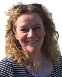

[Claire Jack Ph.D.](https://www.psychologytoday.com/us/contributors/claire-jack-phd)

[Women with Autism Spectrum Disorder](https://www.psychologytoday.com/us/blog/women-autism-spectrum-disorder)

###### [Suicide](https://www.psychologytoday.com/us/basics/suicide)

# 6 Reasons Autistic People Are at Greater Risk of Suicide

## Ongoing research shows an increased link between autism and suicidality. Why?

Posted February 17, 2023 | [Reviewed by Devon Frye](https://www.psychologytoday.com/us/docs/editorial-process)

### Key points

- Autistic people are at far higher risk of suicide than the general population.
- Cognitive inflexibility, mental health issues, and social isolation may all increase autistic people's risk of suicide.
- Family members, friends, and practitioners should be aware of the differences in autistic risk markers for suicide.

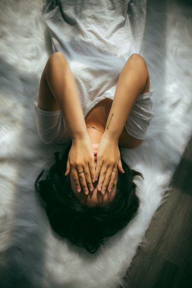

Anthony Tran, Unsplash

Researchers have long been aware of higher [suicidality](https://www.psychologytoday.com/us/basics/suicide) among [autistic](https://www.psychologytoday.com/us/basics/autism) people,<sup>1</sup> including a greater rate of successful suicide attempts compared to the general population. However, recent research suggests that the suicide levels in autistic populations could be even higher than previously thought.

Analysis of records of people who had died by suicide, including people with diagnosed autism and those who had not been diagnosed, revealed that 10.7 percent, including some who were not formally diagnosed, displayed autistic traits. When the researchers interviewed families of a subsample of those people who had died, over 41 percent displayed elevated autistic traits.<sup>2</sup>

## Why Are Autism and Suicidality Linked?

So, why are autistic people more at risk of suicide—and what can be done to help? Our current understanding points to the following factors:

1. **Mental health problems:** Autistic people are more likely to experience concurrent mental health problems, including anxiety and depression, which, particularly if they’re untreated, may lead to a greater risk of suicide.
2. **Late diagnosis:** Many autistic people remain undiagnosed well into adulthood, with women being more likely to receive a late diagnosis (or remain undiagnosed altogether). Late diagnosis is linked with a greater risk of suicidal ideation.<sup>4</sup>
3. **Adverse life events:** Navigating life as an autistic person is often challenging, and autistic people are at greater risk of being bullied, experiencing financial problems, being socially excluded, and facing workplace and relationship problems, any of which may be at the root of suicidality.<sup>5</sup>
4. **[Camouflaging](https://www.psychologytoday.com/us/basics/masking):** Autistic people—particularly those with level 1 autism—often try to “camouflage” their autism, finding ways to mask their symptoms in order to fit in with other people. Camouflaging is mentally burdensome and is linked to higher rates of mental illness and suicidality.<sup>6</sup>
5. **Cognitive inflexibility:** Cognitive flexibility is someone's ability to think about situations in different ways and adjust to evolving circumstances. Autistic people tend to experience a higher degree of inflexibility, which may make it harder for them to see alternatives to suicide as a means to ending the emotional pain or life challenges they may be experiencing.
6. **Isolation:** Autistic people face social and communication problems which can lead to isolation and a lack of support, increasing their risk of suicidality.

## What Can Be Done to Lower the Risk?

If you’re an autistic person (or suspect you might be), here are some ways you can help yourself:

**1. Seek out a diagnosis.**

If you’re struggling, an accurate diagnosis can help you understand your symptoms and seek out appropriate help. Unfortunately, the wait times for a full [psychiatric](https://www.psychologytoday.com/us/basics/psychiatry) diagnosis can be extremely lengthy and, depending on your insurance and other factors, may be expensive. Some therapists (including counsellors and speech therapists) are trained in autism diagnosis which can offer a quicker, more affordable diagnostic option. Note that some workplaces or educational establishments may require a psychiatric diagnosis.

**2. Talk to someone.**

The thought of opening up about suicidal feelings might seem impossible, but talking to someone—whether that's a therapist, friend, teacher, colleague, or family member—is a starting point for sharing how you feel and receiving help to find alternatives to suicide. If you can’t get the words out, consider writing them down. [Seek out appropriate therapy](https://www.psychologytoday.com/us/therapists) to help you deal with suicidal ideation.

**3. Self-care.**

For some people, suicidality is something that is present for much of the time. Finding ways to recognise these thoughts as just that, thoughts, can be helpful. It’s also likely that there are times when suicidal thoughts are more or less heightened. Identifying the types of situations and triggers which can lead to increased feelings of suicide, or which have been present before a suicide attempt, can help you find ways to cope with these situations in advance. Finding ways that help you manage your stress levels, get the rest you need, and nurture your brain in the ways it needs can lead to a general improvement in your mental health.

## What Others Should Know

If you’re the parent, friend, colleague, or family member of an autistic person, or healthcare practitioner, here are some things to consider:

**1. Be aware of camouflaging.**

You might fall into the trap of thinking that because your family member or friend has been diagnosed with level 1 autism (previously known as [Asperger](https://www.psychologytoday.com/us/basics/aspergers-syndrome)’s syndrome), their challenges are less significant; in turn, you might believe this makes them less at risk of suicide than someone who has more substantial learning difficulties and support needs. In fact, the opposite is true: People with level 1 autism are *more* likely to experience suicidal ideation, often due to their need to camouflage their symptoms and stay productive in a world not designed for their needs.

**2. Suicidality can be different in autistic people.**

Research has shown that autistic people don’t necessarily fit into the usual patterns of people who are at higher risk of suicide. One study showed that far more people with Asperger’s syndrome experienced suicidal ideation than depression, which suggests a different route to suicidality in autistic people when compared to the general population.<sup>7</sup>

We also know that autistic women who don’t have learning difficulties are most at risk of dying by suicide.<sup>8</sup>This is in contrast to women in general, who typically are less at risk of dying of suicide than men.<sup>9</sup>

Another difference that autistic people may experience is heightened perseverance and repetitiveness of suicidal thoughts and a greater likelihood of impulsively attempting suicide without a plan.<sup>10</sup>

**3. Find ways to listen and communicate.**

Describing how one is feeling is often incredibly hard for an autistic person. Thus, if an autistic person opens up to you, or you are worried that they might be at risk of suicide, it's critical that you listen to what they are saying.

You may have the temptation to reassure them that everything is OK or find an immediate "solution" to the problems they describe. But it’s important to remember that processing times may be slower among autistic adults, particularly when they're experiencing distress. You need to create time and space so that they can express themselves, in whatever way is right for them.

Ask clear questions. Avoid talking in metaphors or finding indirect ways of talking about suicide. Most importantly, stay calm and seek out support for yourself and your loved one.

*If you or someone you love is contemplating suicide, seek help immediately. For help 24/7 in the U.S., dial 988 for the National Suicide Prevention Lifeline, or reach out to the Crisis Text Line by texting TALK to 741741. Outside of the U.S., visit the [International Resources page for suicide hotlines in your country.](https://www.psychologytoday.com/us/basics/suicide/suicide-prevention-hotlines-resources-worldwide) To find a therapist near you, see the [Psychology Today Therapy Directory](https://www.psychologytoday.com/us/therapists).*

References

1. Cassidy, S. Suicidality and self-harm in autism spectrum conditions. In Oxford Handbook of Autism and Co-Occurring Psychiatric Conditions (eds White, S, Maddox, B, Mazefsky, C): 349–68. Oxford University Press, 2020.[Google Scholar](https://scholar.google.com/scholar_lookup?title=Oxford+Handbook+of+Autism+and+Co-Occurring+Psychiatric+Conditions&author=Cassidy+S&author=White+S&author=Maddox+B&author=Mazefsky+C&publication+year=2020)

2. Cassidy, S, Au-Yeung, S, Robertson, A et. Al. (2022) Autism and autistic traits in those who died by suicide in England. The British Journal of Psychiatry, 221 (5) 683-691

3. Richards, G, Kenny, R, Griffiths, S, Allison, C, Mosse, D, Holt, R, et al. Autistic traits in adults who have attempted suicide. Mol Autism 2019; 10: 26.[CrossRef](http://dx.doi.org/10.1186/s13229-019-0274-4)Google Scholar[PubMed](http://www.ncbi.nlm.nih.gov/pubmed/31198526)

4. Cassidy, S, Bradley, P, Robinson, J, Allison, C, McHugh, M, Baron-Cohen, S. Suicidal ideation and suicide plans or attempts in adults with Asperger's syndrome attending a specialist diagnostic clinic: a clinical cohort study. Lancet Psychiatry 2014; 1: 142–7.CrossRefGoogle Scholar[PubMed](http://www.ncbi.nlm.nih.gov/pubmed/26360578)

5. Griffiths, S, Allison, C, Kenny, R, Holt, R, Smith, P, Baron-Cohen, S. The vulnerability experiences quotient (VEQ): a study of vulnerability, mental health and life satisfaction in autistic adults. Autism Res 2019; 12: 1516–28.[CrossRef](http://dx.doi.org/10.1002/aur.2162)Google Scholar[PubMed](http://www.ncbi.nlm.nih.gov/pubmed/31274233)

6. Cassidy, SA, Gould, K, Townsend, E, Pelton, M, Robertson, AE, Rodgers J. Is Camouflaging Autistic Traits Associated with Suicidal Thoughts and Behaviours? Expanding the Interpersonal Psychological Theory of Suicide in an Undergraduate Student Sample. J Autism Dev Disord. 2020 Oct;50(10):3638-3648. doi: 10.1007/s10803-019-04323-3. PMID: 31820344; PMCID: PMC7502035.

7. Cassidy, S, Bradley, P, Robinson, J, Allison, C, McHugh, M, Baron-Cohen, S Suicidal ideation and suicide plans or attempts in adults with Asperger's syndrome attending a specialist diagnostic clinic: a clinical cohort study. *Lancet Psychiatry.* 2014; 1: 142-147

8. Hirvikoski, T, Mittendorfer-Rutz, E, Boman, M, Larsson, H, Lichenstein, P, Bolte, S Premature mortality in autism spectrum disorder.*Br J Psychiatry.* 2016; 208: 232-238

9. Coope, C, Gunnell, D, Hollingworth, W et al. Suicide and the 2008 economic recession: who is most at risk? Trends in suicide rates in England and Wales 2001–2011. *Soc Sci Med.* 2014; 117: 76-85

10. Cassidy, SA, Bradley, L, Cogger-Ward, H, Shaw, R, Bowen, E, Glod, M, et al. Measurement properties of the suicidal behaviour questionnaire-revised in autistic adults. J Autism Dev Disord 2020; 50: 3477–88.[CrossRef](http://dx.doi.org/10.1007/s10803-020-04431-5)Google Scholar[PubMed](http://www.ncbi.nlm.nih.gov/pubmed/32125569)

About the Author

**Claire Jack, Ph.D.**, is a hypnotherapist, life coach, researcher, and training provider who specialises in working with women with autism spectrum disorder (ASD). She was herself diagnosed with ASD in her forties.

Online:

[Autism Assessment Online](https://www.autism-assessment-online.com/resources), [Facebook](https://www.facebook.com/drclairejack), [Instagram](https://www.instagram.com/autisticadulttherapy/), [LinkedIn](https://www.linkedin.com/in/autisticadults/)

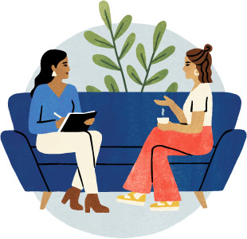

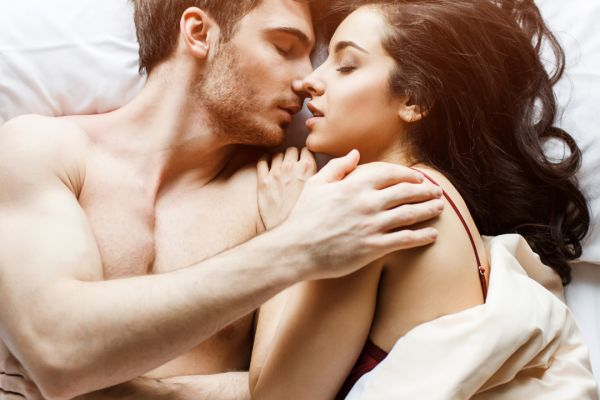

###### [Sex](https://www.psychologytoday.com/us/basics/sex)

5 Min Read

Sensory processing differences can lead to differences in autistic people’s experience of sex.

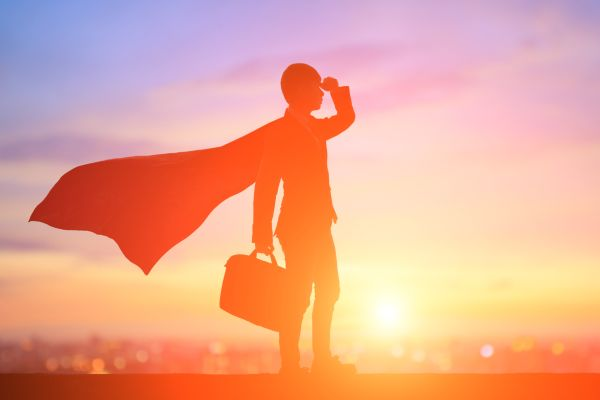

###### [Autism](https://www.psychologytoday.com/us/basics/autism)

3 Min Read

In general, autistic people are more likely than others to be unemployed or underemployed.

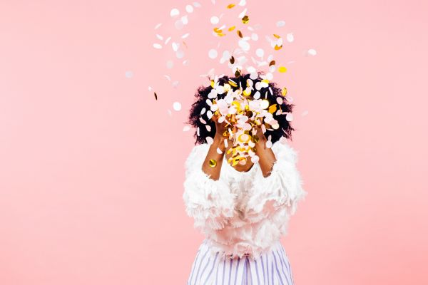

###### [Autism](https://www.psychologytoday.com/us/basics/autism)

2 Min Read

The year's Autism Acceptance Month's theme is "Celebrating Differences."

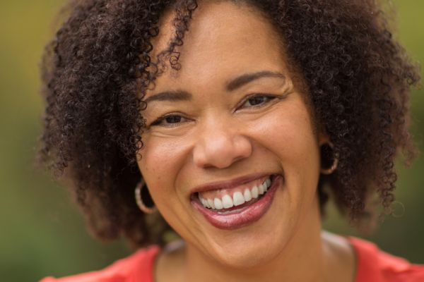

###### [Menopause](https://www.psychologytoday.com/us/basics/menopause)

4 Min Read

Research shows that being autistic can shape a woman's experience of menopause.

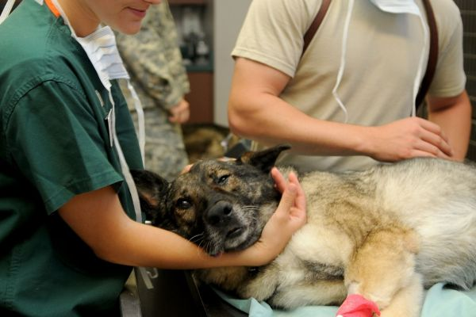

###### [Suicide](https://www.psychologytoday.com/us/basics/suicide)

6 Min Read

A study reports about 80% of veterinarians suffer from clinical depression at some point.

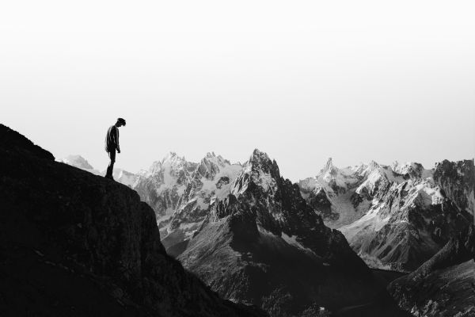

###### [Suicide](https://www.psychologytoday.com/us/basics/suicide)

4 Min Read

Feelings of hopelessness and despair are common human experiences.

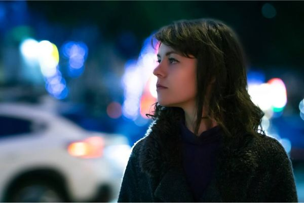

###### [Self Tests](https://www.psychologytoday.com/us/tests)

3 min

Are you experiencing depression?

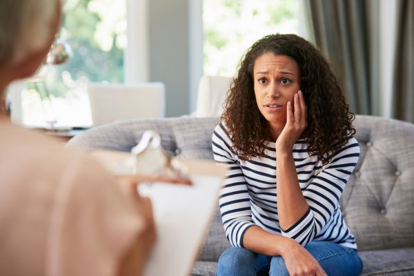

###### [Suicide](https://www.psychologytoday.com/us/basics/suicide)

5 Min Read

Mental health clinicians are trained to navigate discussions about self-harm.

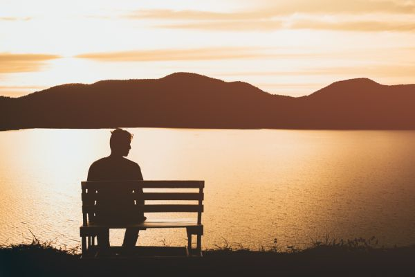

###### [Suicide](https://www.psychologytoday.com/us/basics/suicide)

5 Min Read

After someone commits suicide, the most common question their loved ones ask is, "Why?"

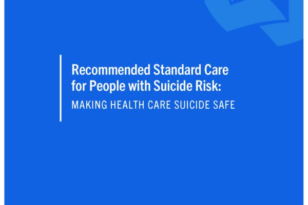

###### [Suicide](https://www.psychologytoday.com/us/basics/suicide)

4 Min Read

Common sense clinical recommendations for suicide risk exist but are not widely used.

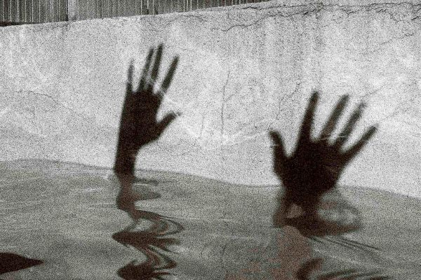

###### [Suicide](https://www.psychologytoday.com/us/basics/suicide)

3 Min Read

Every year 10 million U.S. adults experience suicidal thoughts and 1.7 million attempt suicide.

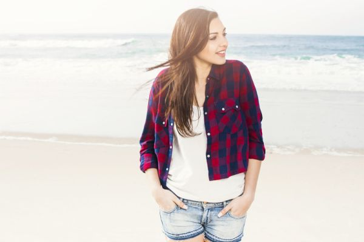

###### [Suicide](https://www.psychologytoday.com/us/basics/suicide)

4 Min Read

While many young people flirt with the idea of committing suicide, adults hesitate to speak about the problem openly.

Back

Back

Personal Growth

Relationships

Family Life

Do I Need Help?

- Self Tests

Recently Diagnosed?

Talk to Someone

Back

Magazine

[figure not shown]

May 2024

How to Face Your Everyday Triggers

Back

Today

News

Essential Reads

Trending Topics